# IC-Case 31- Summary of Data Analysis for R3, R6, and R4

Author

Alexa Bueno

```r
library(haven)
library(dplyr)
library(tidyr)
library(ggplot2)
library(knitr)
library(psych)

theme_set(theme_minimal(base_size = 13))

# Cleaned Case 31 file (efcu_4). Reversed items (q9_r, q10_r, Q37_r, q13_r...) are already in it.
# The file also has a leftover SPSS filter variable (filter_$). I ignore it so all 128 members are used.
data <- read_sav("Case 31 Data_efcu_4.sav")

data <- data |>
  mutate(
    # q12 has a code 3 with no value label, so I treat it as missing (same as the last in-class activity)
    q12 = na_if(as.numeric(q12), 3),
    # Member residence: 1 = lives in the HQ area, 2 = lives elsewhere
    residence = factor(as.numeric(q38), levels = c(1, 2),
                       labels = c("HQ area", "Elsewhere"))
  )

# One group t-test against a test value, returned as one table row
one_t <- function(x, mu, item) {
  x <- as.numeric(x); x <- x[!is.na(x)]
  res <- t.test(x, mu = mu)
  tibble(Item = item, n = length(x), Mean = round(mean(x), 2), SD = round(sd(x), 2),
         `Test value` = mu, t = round(unname(res$statistic), 2),
         df = unname(res$parameter),
         p = format.pval(res$p.value, digits = 3, eps = 0.001))
}

# Independent groups t-test (HQ area vs elsewhere), returned as one table row
two_t <- function(var, item) {
  d <- data |> transmute(y = as.numeric(.data[[var]]), g = residence) |> filter(!is.na(y))
  a <- d$y[d$g == "HQ area"]; b <- d$y[d$g == "Elsewhere"]
  res <- t.test(a, b)  # Welch version, does not assume equal variances
  # Levene's test (mean-centered) written by hand to avoid another package
  lev <- anova(lm(abs(d$y - ave(d$y, d$g)) ~ d$g))$`Pr(>F)`[1]
  sp <- sqrt(((length(a) - 1) * var(a) + (length(b) - 1) * var(b)) / (length(a) + length(b) - 2))
  tibble(Item = item,
         `HQ M` = round(mean(a), 2), `HQ SD` = round(sd(a), 2),
         `Else M` = round(mean(b), 2), `Else SD` = round(sd(b), 2),
         t = round(unname(res$statistic), 2), df = round(unname(res$parameter), 1),
         p = format.pval(res$p.value, digits = 3, eps = 0.001),
         d = round((mean(a) - mean(b)) / sp, 2),
         `Levene p` = format.pval(lev, digits = 3, eps = 0.001))
}

# Percent table for one item
pct_table <- function(x) {
  as_factor(x) |> table(useNA = "no") |> prop.table() |>
    (\(p) round(p * 100, 1))() |> as.data.frame() |> setNames(c("Response", "Percent"))
}
```

# Overview

This report covers R3, R6, and R4 (a, b, c) for Case 31, the Employees Federal Credit Union survey (128 members). Following the instructions, I looked at frequencies and means first, thought about the story, and then used tests to check it. Test results are in parentheses so they don’t get in the way. All tests use an alpha of .05.

| RQ | Question | Test used |
| --- | --- | --- |
| R3 | Attitudes about employee proficiencies | Descriptive statistics, reliability check, one group t-test |
| R6 | Attitudes about how effectively the CU is operated | Descriptive statistics, one group t-test |
| R4a | HQ area vs. elsewhere: attitude toward employees | Descriptive statistics, independent groups t-test |
| R4b | HQ area vs. elsewhere: awareness of services | Cross-tabulation, chi-square independence test |
| R4c | HQ area vs. elsewhere: operational effectiveness | Descriptive statistics, independent groups t-test and chi-square independence test |

# R3: Attitudes toward employee proficiencies

## Descriptive Statistics

```r
items3 <- c(q3 = "Q3 Courteous", q4 = "Q4 Helpful", q5 = "Q5 Professional", q6 = "Q6 Available")

bind_rows(lapply(names(items3), function(v) {
  x <- as.numeric(data[[v]])
  tibble(Item = items3[[v]], n = sum(!is.na(x)), Mean = round(mean(x), 2), SD = round(sd(x), 2),
         `% Agree or Strongly Agree` = round(mean(x >= 4) * 100, 1))
})) |>
  bind_rows(tibble(Item = "Att_employee (average of Q3 to Q6)", n = sum(!is.na(data$Att_employee)),
                   Mean = round(mean(data$Att_employee), 2), SD = round(sd(data$Att_employee), 2),
                   `% Agree or Strongly Agree` = round(mean(data$Att_employee >= 4) * 100, 1))) |>
  kable()
```

Table 1: R3: Employee proficiency items (1 = Strongly Disagree, 5 = Strongly Agree)

| Item | n | Mean | SD | % Agree or Strongly Agree |
| --- | --- | --- | --- | --- |
| Q3 Courteous | 128 | 4.35 | 0.66 | 89.8 |
| Q4 Helpful | 128 | 4.31 | 0.70 | 88.3 |
| Q5 Professional | 128 | 4.08 | 0.66 | 82.0 |
| Q6 Available | 128 | 4.08 | 0.79 | 78.9 |
| Att_employee (average of Q3 to Q6) | 128 | 4.21 | 0.59 | 75.8 |

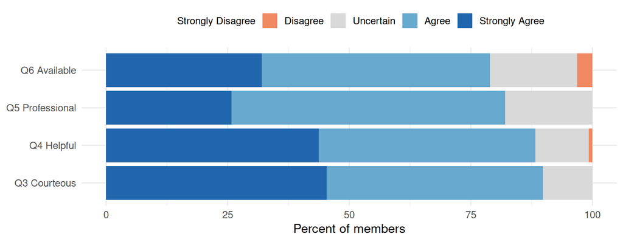

Figure 1: R3: Responses to the four employee proficiency items

```r
data |>
  select(q3:q6) |>
  mutate(across(everything(), as.numeric)) |>
  pivot_longer(everything(), names_to = "item", values_to = "value") |>
  mutate(item = recode(item, !!!items3),
         value = factor(value, levels = 1:5,
                        labels = c("Strongly Disagree", "Disagree", "Uncertain", "Agree", "Strongly Agree"))) |>
  count(item, value) |>
  group_by(item) |>
  mutate(pct = n / sum(n) * 100) |>
  ggplot(aes(x = pct, y = item, fill = value)) +
  geom_col() +
  scale_fill_manual(values = c("#b2182b", "#ef8a62", "#d9d9d9", "#67a9cf", "#2166ac"), drop = FALSE) +
  labs(x = "Percent of members", y = NULL, fill = NULL) +
  theme(legend.position = "top")
```

## Reliability Check

Before using the four items as one measure, I did a quick check that they hang together. If this was already reported in the earlier reliability and factor analysis activity, this is only a reminder.

```r
emp <- data |> select(q3:q6) |> zap_labels()
a <- psych::alpha(emp)
f <- psych::fa(emp, nfactors = 1, fm = "pa")

tibble(Item = items3,
       `Factor loading` = round(as.numeric(f$loadings), 2)) |>
  bind_rows(tibble(Item = "Cronbach's alpha", `Factor loading` = round(a$total$raw_alpha, 2))) |>
  kable()
```

Table 2: R3: Reliability and one-factor check for Q3 to Q6

| Item | Factor loading |
| --- | --- |
| Q3 Courteous | 0.72 |
| Q4 Helpful | 0.92 |
| Q5 Professional | 0.79 |
| Q6 Available | 0.73 |
| Cronbach’s alpha | 0.87 |

## One Group t-test

```r
bind_rows(
  one_t(data$q3, 3, "Q3 Courteous"),
  one_t(data$q4, 3, "Q4 Helpful"),
  one_t(data$q5, 3, "Q5 Professional"),
  one_t(data$q6, 3, "Q6 Available"),
  one_t(data$Att_employee, 3, "Att_employee (composite)")
) |> kable()
```

Table 3: R3: One group t-tests against 3 (Uncertain)

| Item | n | Mean | SD | Test value | t | df | p |
| --- | --- | --- | --- | --- | --- | --- | --- |
| Q3 Courteous | 128 | 4.35 | 0.66 | 3 | 23.20 | 127 | <0.001 |
| Q4 Helpful | 128 | 4.31 | 0.70 | 3 | 21.34 | 127 | <0.001 |
| Q5 Professional | 128 | 4.08 | 0.66 | 3 | 18.50 | 127 | <0.001 |
| Q6 Available | 128 | 4.08 | 0.79 | 3 | 15.44 | 127 | <0.001 |
| Att_employee (composite) | 128 | 4.21 | 0.59 | 3 | 22.95 | 127 | <0.001 |

## What It Means

- Members think highly of the employees. The composite averages 4.21 out of 5 and 75.8% of members average “Agree” or higher (Table 1).
- Courteous (89.8% agree) and helpful (88.3%) are the strongest items. Being professional (82.0%) and available (78.9%) score a little lower, but they are still clearly positive (Figure 1).
- The four items are highly consistent with each other (alpha = .87, one factor with loadings that are all strong), so combining them into one score makes sense (Table 2).
- Every item and the composite are well above “Uncertain” (composite: t(127) = 22.95, p < .001; all four items p < .001, Table 3). This is a strength the credit union can build on. The employees are a reason to stay, not a problem to fix.

# R6: Attitudes toward how effectively the CU is operated

The reliability check for Q31 to Q34 was already reported in the previous activity (alpha = .47, too low to combine), so I keep these as separate items and don’t repeat it here.

## Descriptive Statistics

```r
bind_rows(
  pct_table(data$q11) |> mutate(Item = "Q11 Statements easy to understand"),
  pct_table(data$q12) |> mutate(Item = "Q12 Accounts kept confidential (n = 106)")
) |> select(Item, Response, Percent) |> kable()
```

Table 4: R6: Yes/No items, percent of members who answered

| Item | Response | Percent |
| --- | --- | --- |
| Q11 Statements easy to understand | Yes | 97.7 |
| Q11 Statements easy to understand | No | 2.3 |
| Q12 Accounts kept confidential (n = 106) | 1 | 69.8 |
| Q12 Accounts kept confidential (n = 106) | 2 | 30.2 |

```r
bind_rows(
  one_t(data$q9_r, 3, "Q9r Statement frequency (3 = About Right)"),
  one_t(data$q10_r, 2.5, "Q10r Statement accuracy (1 = Poor, 4 = Excellent)"),
  one_t(data$q31, 3, "Q31 Personnel keep info confidential"),
  one_t(data$q32, 3, "Q32 Prompt in processing loan applications"),
  one_t(data$q33, 3, "Q33 Services meet members' needs"),
  one_t(data$q34, 3, "Q34 Loan applications simple and easy"),
  one_t(data$Q37_r, 3, "Q37r Overall rating of management and operation")
) |> kable()
```

Table 5: R6: Interval items, one group t-tests against the scale midpoint

| Item | n | Mean | SD | Test value | t | df | p |
| --- | --- | --- | --- | --- | --- | --- | --- |
| Q9r Statement frequency (3 = About Right) | 128 | 2.77 | 0.42 | 3.0 | -6.10 | 127 | <0.001 |
| Q10r Statement accuracy (1 = Poor, 4 = Excellent) | 128 | 3.47 | 0.64 | 2.5 | 17.15 | 127 | <0.001 |
| Q31 Personnel keep info confidential | 128 | 3.95 | 0.68 | 3.0 | 15.74 | 127 | <0.001 |
| Q32 Prompt in processing loan applications | 128 | 3.72 | 0.79 | 3.0 | 10.25 | 127 | <0.001 |
| Q33 Services meet members’ needs | 128 | 3.59 | 0.68 | 3.0 | 9.87 | 127 | <0.001 |
| Q34 Loan applications simple and easy | 128 | 3.46 | 0.78 | 3.0 | 6.66 | 127 | <0.001 |
| Q37r Overall rating of management and operation | 121 | 4.07 | 0.73 | 3.0 | 16.12 | 120 | <0.001 |